# Explore And Summarize_Wine

Maitrayee Ranade Bordikar

July 13, 2017

========================================================

This report is on exploration of the wine qualities data set both Whites and Reds (P. Cortez, A. Cerdeira, F. Almeida and Reis. 2009). Below is information about the datasets from the Authors.

The two datasets are related to red and white variants of the Portuguese “Vinho Verde” wine. For more details, consult: http://www.vinhoverde.pt/en/ or the reference (P. Cortez, A. Cerdeira, F. Almeida and Reis. 2009). Due to privacy and logistic issues, only physicochemical (inputs) and sensory (the output) variables are available (e.g. there is no data about grape types, wine brand, wine selling price, etc.).

These datasets can be viewed as classification or regression tasks. The classes are ordered and not balanced (e.g. there are munch more normal wines than excellent or poor ones). Outlier detection algorithms could be used to detect the few excellent or poor wines. Also, we are not sure if all input variables are relevant. So it could be interesting to test feature selection methods.

Number of Instances: red wine - 1599; white wine - 4898.

Number of Attributes: 11 + output attribute

Description of attributes:

1 - fixed acidity: most acids involved with wine or fixed or nonvolatile (do not evaporate readily)

2 - volatile acidity: the amount of acetic acid in wine, which at too high of levels can lead to an unpleasant, vinegar taste

3 - citric acid: found in small quantities, citric acid can add ‘freshness’ and flavor to wines

4 - residual sugar: the amount of sugar remaining after fermentation stops, it’s rare to find wines with less than 1 gram/liter and wines with greater than 45 grams/liter are considered sweet

5 - chlorides: the amount of salt in the wine

6 - free sulfur dioxide: the free form of SO2 exists in equilibrium between molecular SO2 (as a dissolved gas) and bisulfite ion; it prevents microbial growth and the oxidation of wine

7 - total sulfur dioxide: amount of free and bound forms of S02; in low concentrations, SO2 is mostly undetectable in wine, but at free SO2 concentrations over 50 ppm, SO2 becomes evident in the nose and taste of wine

8 - density: the density of water is close to that of water depending on the percent alcohol and sugar content

9 - pH: describes how acidic or basic a wine is on a scale from 0 (very acidic) to 14 (very basic); most wines are between 3-4 on the pH scale

10 - sulphates: a wine additive which can contribute to sulfur dioxide gas (S02) levels, wich acts as an antimicrobial and antioxidant

11 - alcohol: the percent alcohol content of the wine

Output variable (based on sensory data): 12 - quality (score between 0 and 10)

Since both the datasets have same set of variables, I am combinging the two sets and creating a new attribute of color to differentiate. The analysis could show some ineteresting results while comaparing Red and White wines.

The code below loads all the libraries needed for the analysis.

Loading dataset below, combing it to form one dataframe. Creating another variable of color to identify red or white wine.

Data Summary:

```
## 'data.frame':    6497 obs. of  14 variables:
##  $ X                   : int  1 2 3 4 5 6 7 8 9 10 ...
##  $ fixed.acidity       : num  7 6.3 8.1 7.2 7.2 8.1 6.2 7 6.3 8.1 ...
##  $ volatile.acidity    : num  0.27 0.3 0.28 0.23 0.23 0.28 0.32 0.27 0.3 0.22 ...
##  $ citric.acid         : num  0.36 0.34 0.4 0.32 0.32 0.4 0.16 0.36 0.34 0.43 ...
##  $ residual.sugar      : num  20.7 1.6 6.9 8.5 8.5 6.9 7 20.7 1.6 1.5 ...
##  $ chlorides           : num  0.045 0.049 0.05 0.058 0.058 0.05 0.045 0.045 0.049 0.044 ...
##  $ free.sulfur.dioxide : num  45 14 30 47 47 30 30 45 14 28 ...
##  $ total.sulfur.dioxide: num  170 132 97 186 186 97 136 170 132 129 ...
##  $ density             : num  1.001 0.994 0.995 0.996 0.996 ...
##  $ pH                  : num  3 3.3 3.26 3.19 3.19 3.26 3.18 3 3.3 3.22 ...
##  $ sulphates           : num  0.45 0.49 0.44 0.4 0.4 0.44 0.47 0.45 0.49 0.45 ...
##  $ alcohol             : num  8.8 9.5 10.1 9.9 9.9 10.1 9.6 8.8 9.5 11 ...
##  $ quality             : int  6 6 6 6 6 6 6 6 6 6 ...
##  $ color               : chr  "White" "White" "White" "White" ...
```

The combined datsett now has 12 input variables and 1 output variables. And a total of 6497 observations.

This report is divided into explroring single variables at a time, then two variables followed by multiple variables.

# Univariate Plots Section

Since I will be looking at the variables of Red and White wines simultaneosly, I am using the multiplot function(Chang, n.d., Winston) to print plots in grid format.

Looing at the quality of wines in the database.

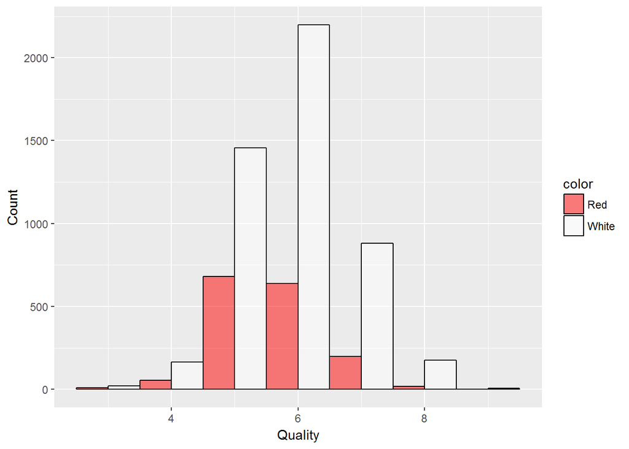

The wine quality ratings is normally distributed with its mean equal to 5.87 and 5.63 for White and Red wines respetively. Next, taking alook at the input variables that could determine the quality ratings of wine begining with alcohol and pH.

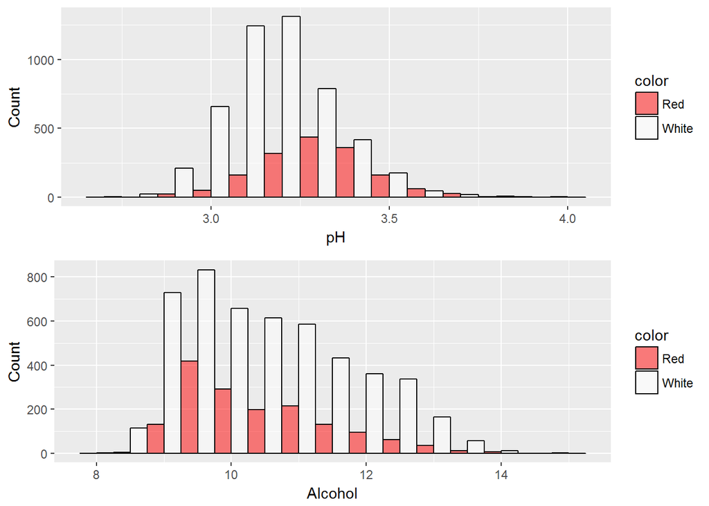

Both pH and alcohol levels are normally disctributed but alcohol distribution is slightly skewed. pH levels for both red and white wine is between 2.75-3.75. Alcohol percentage for both most of the White and Red wines is between 9% and 11 %.

Next looking at the different acidities.

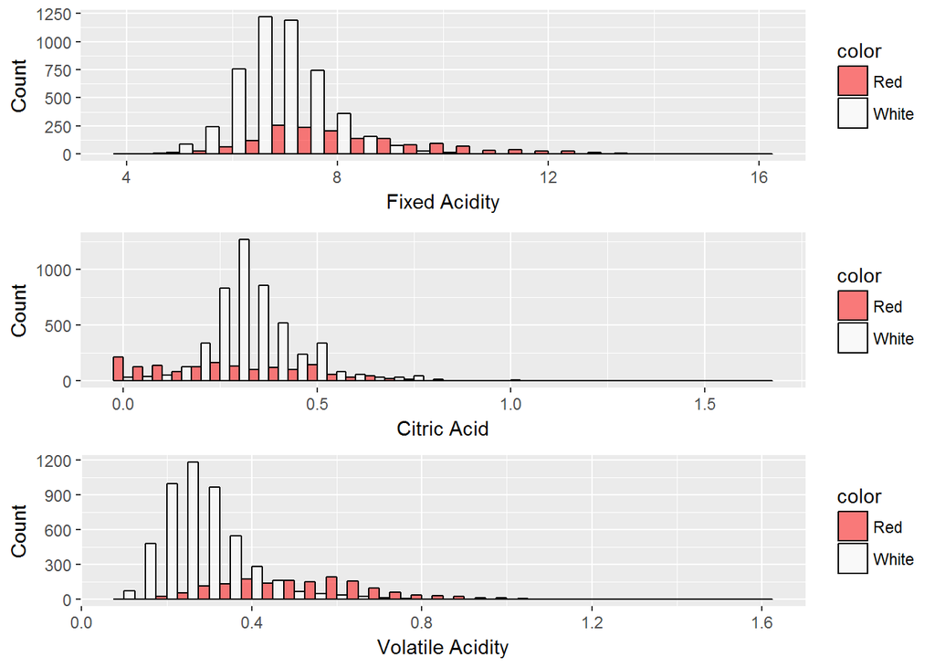

For white wines both the acidity levels and citric acid is normally distributed with mean and median comparable to each other. For red wines the citric acid level distribution is more skewed with the peak at 0. Could this be because Red wines are considered sweeter compared to White wines?

Next looking at the residual sugar.

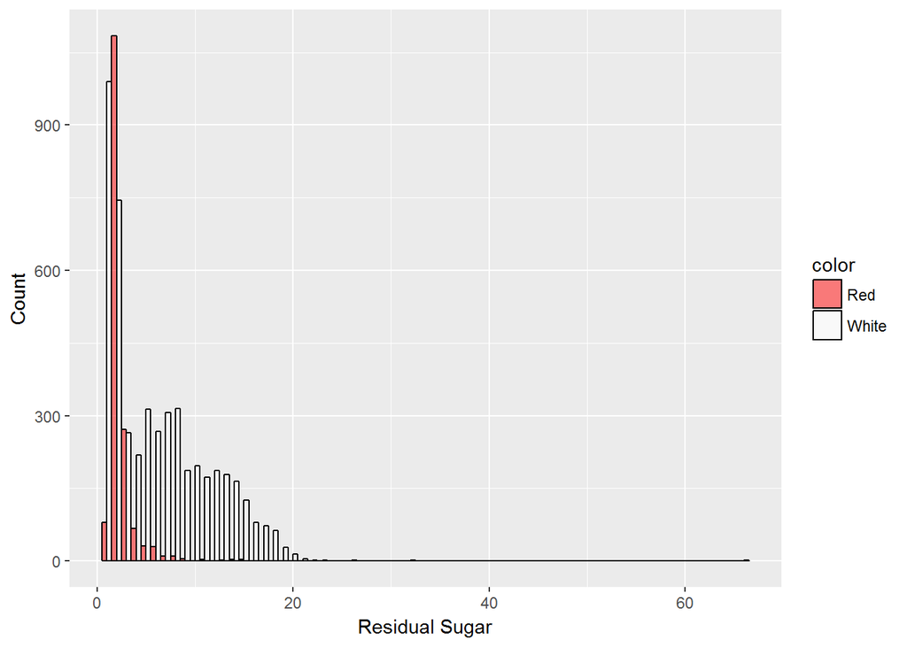

The distribution of residual sugar is skewed with most of Red and White wines having sugar less than 5. Red wines appear to have more samples with sugar less than 5. It will be interesting to see how the quality of the wine is affected by the sweetness of the wine.

Residual Sugar and Citric acid has skewed distribution, so looking at them in box plots.

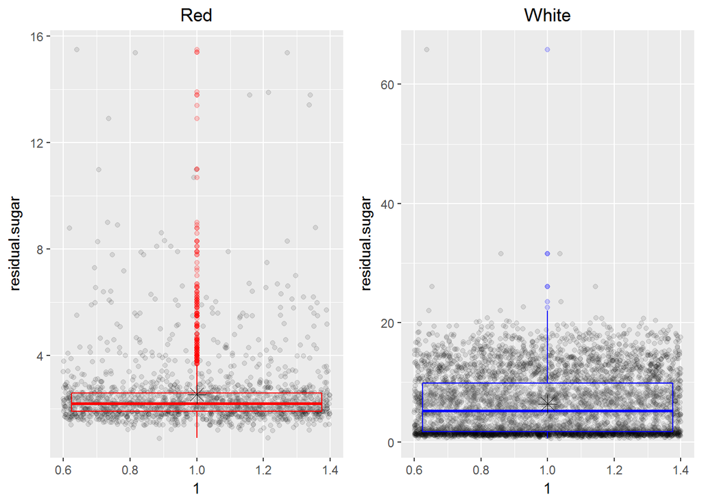

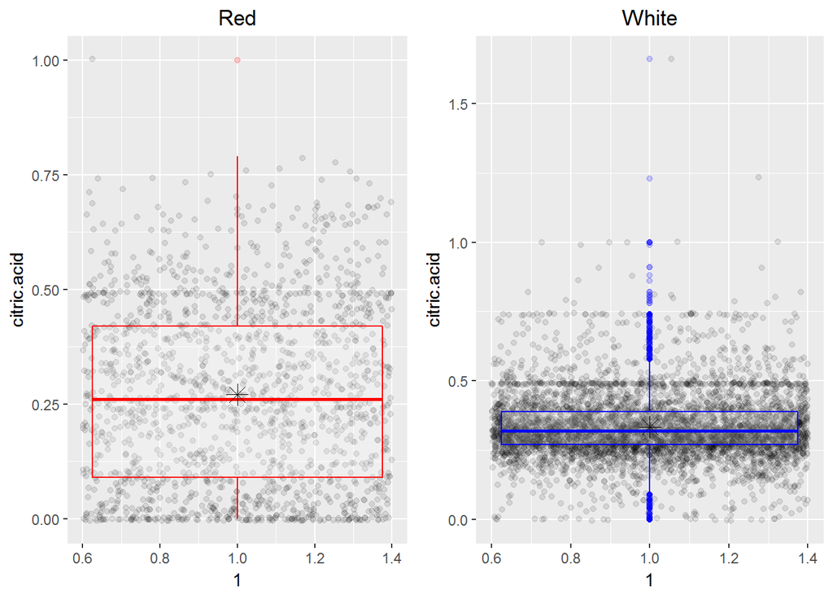

Red wine has many outliers for residual sugar, while white wine has many outliers for citric acid. Looking at density of both the wine types, with histogram and boxplot.

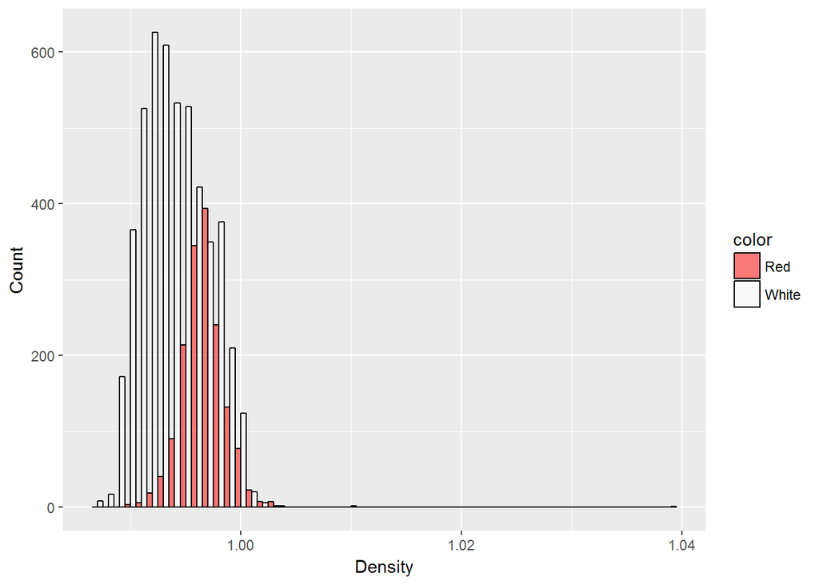

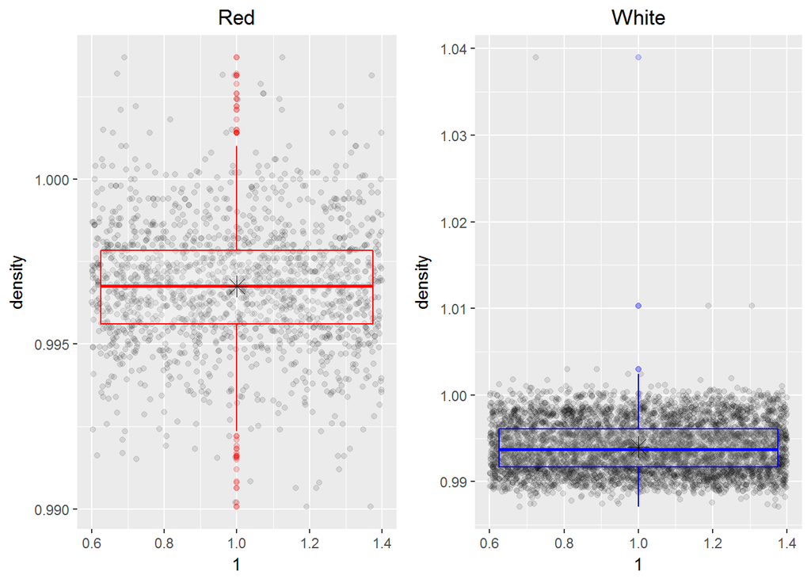

The mean of density for both wine types is comaprable but Red wine has more outliers. Next looking at sulphates and chlorides of the wines.

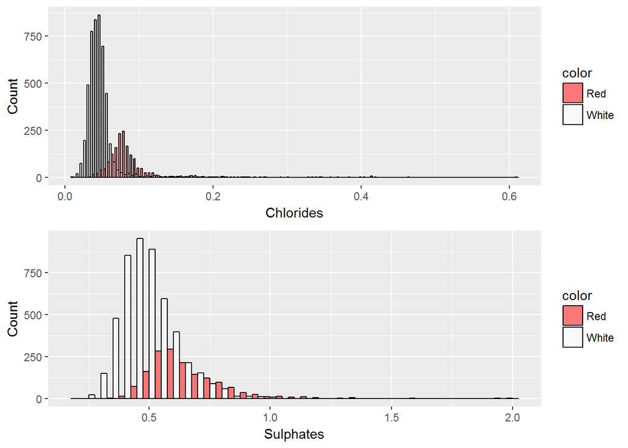

For both Red and White wines the cholrides and sulphates distribution is normal but its mean is shifted with respect to eah other. Red’s chloride mean (0.087) is higher than White’s mean (0.046). And Red’s sulphates mean (0.66) is also higher than White’s (0.49).

# Univariate Analysis

### What is/are the main feature(s) of interest in your dataset?

The main feature I would like to ivestigate is how the quality of wines is determined by its other features such as acidity, sugar, chlorides and sulphates etc.

### What other features in the dataset do you think will help support your investigation into your feature(s) of interest?

Note that all the features have numeric values and not factors. Their inter-relation and its effect on the wine quality will be intersting to explore.

### Did you create any new variables from existing variables in the dataset?

This dataset is a tidy data set so I did not have to perform any data wrangling.

### Of the features you investigated, were there any unusual distributions? Did you perform any operations on the data to tidy, adjust, or change the form of the data? If so, why did you do this?

All the variables in the data set have a numeric value and not factors. It will be interesting to explore the variables (quality, alcohol) by factorizing them and checking its dependancy on other variables. This analysis is in the next section.

# Bivariate Plots Section

Factorizing wine quality into 3 categories poor (quality <= 5.2), fine (5.2 > quality <=7.2) and excellent (quality > 7.2). Also, factorizing alcohol (%) into 5 categories light (alcohol(%) <= 10.0), medium-low (10.0 < alcohol(%) <= 11.5), medium (11.5 < alcohol(%) <= 13.5), medium-high (13.5 < alcohol(%) <= 15) and high (alcohol(%) >15).

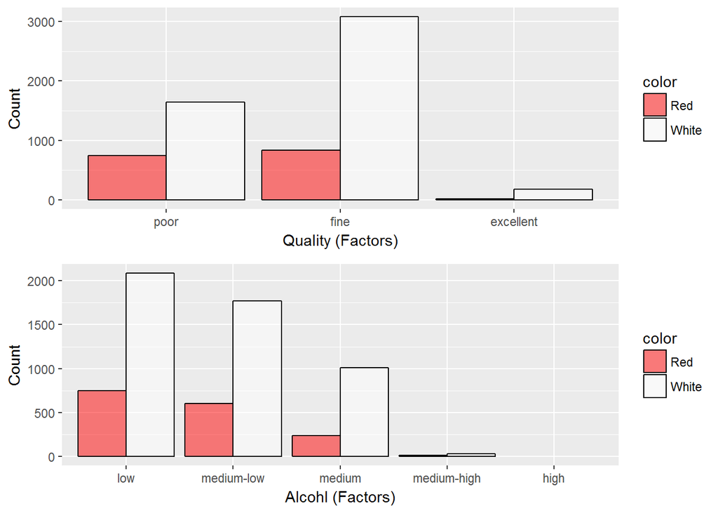

Plotting the correlation coefficient between variables for each type of wine. Created a separate subset for red and white wine with just the input and output variables. Using the corrplot library to plot the correlation matrix. (Kassambra, n.d.)

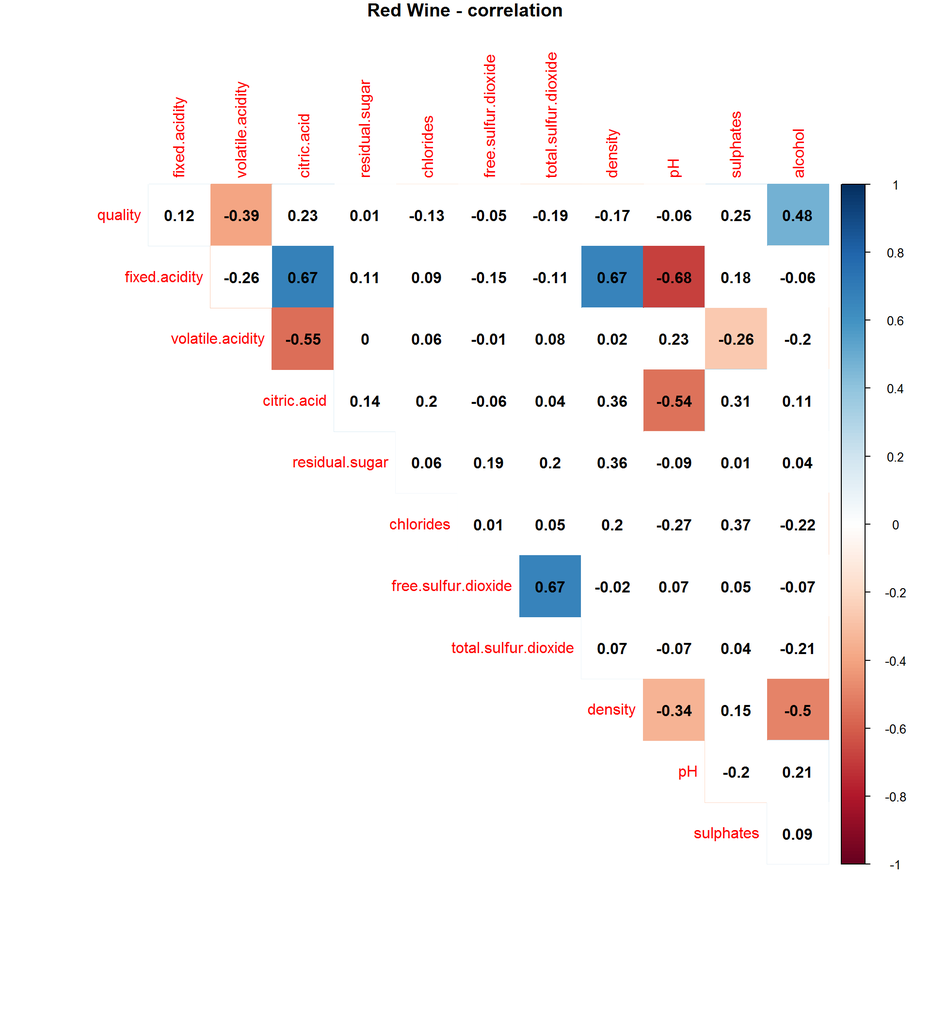

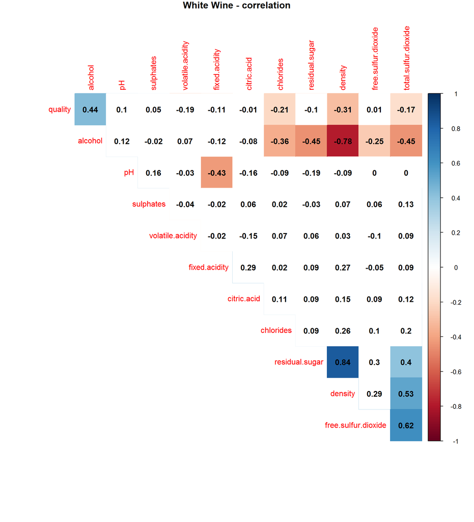

The correlation matrix shows only the significant correlation coefficient between all the variables for each of the wine types separately. For both Red and White wine the quality of wine has positive correlation with alochol of approx 0.45. Red’s quality also has a significant correlation of approx - 0.4 with its volatile acidity. While whites’ quality has significant correlation with density, cholrides and total-sulphur-dioxide of -0.31, -0.21 and -0.17 respetively.

Exploring alcohol and quality relation.

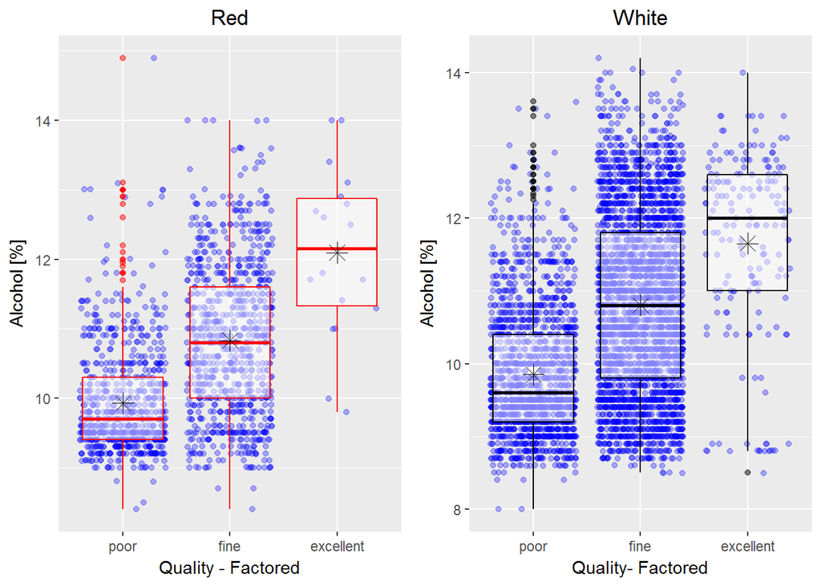

Both wine types have more fine wines. Alcohol percentage is less in poor wines and it increases with wine quality. Although, poor wine has more outliers with higher alcohol percentage levels. The mean of alcohol for each wine type and quality is comparable. Next looking at the relation between density and alcohol for each wines.

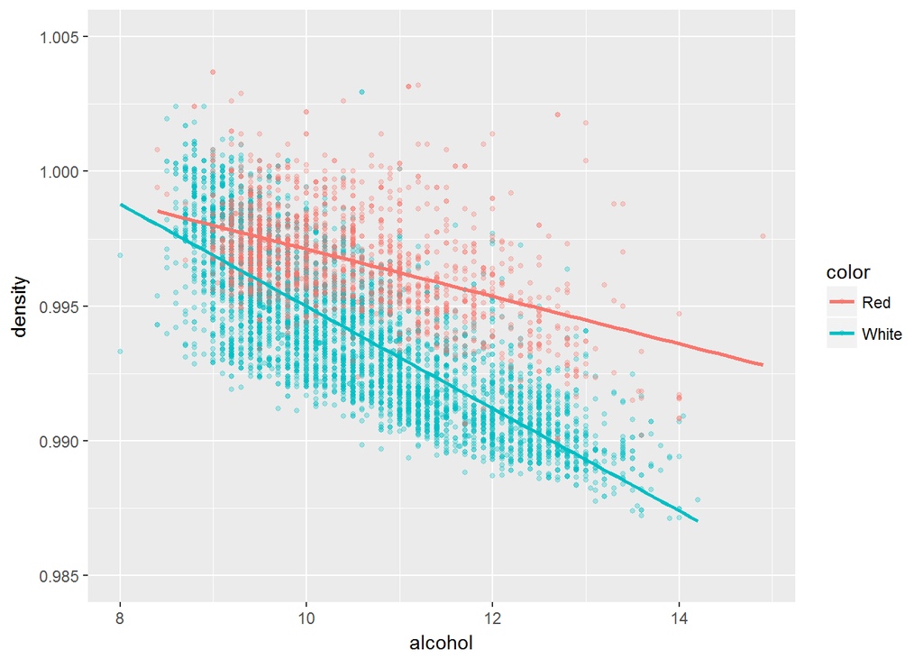

Density and alcohol is more related in case of white wine. The second most significant variable for Red wine is volatile acidity. Looking at volatile acidity and alcohol relation.

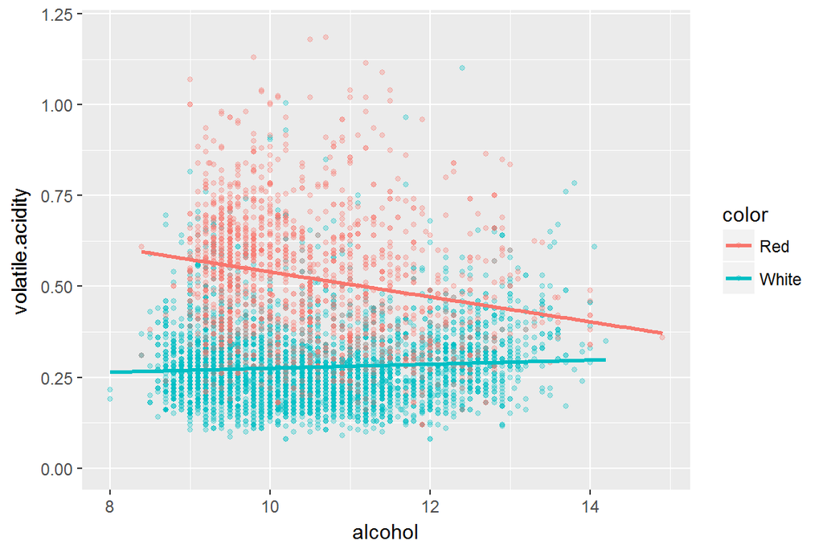

The regression lines show that correlation of volatile acidity and alcohol is more in Red wine.

# Bivariate Analysis

### Talk about some of the relationships you observed in this part of the investigation. How did the feature(s) of interest vary with other features in the dataset?

The correlation matrix shows correlation coefficients between each of the variables for both Red and White wines. It is interesting to note that the quality of wine is positively correlated with its alcohol level for both Red and White wine.

### What was the strongest relationship you found?

Red Wine: 1) between alcohol and quality 2) between volatile acidity and quality 3) between fixed acidity and pH, density and citric acid.

White Wine: 1) between alcohol and quality 2) between density and quality 3) between density and alcohol and residual sugar.

# Multivariate Plots Section

Looking at Red and White wine indivudually next. Refering to the correlation matrix and comparing the two most significant variables determining the wine quality below.

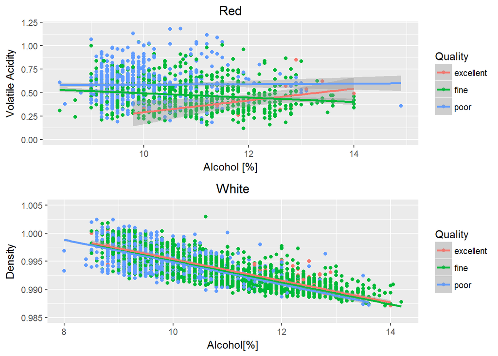

The scatterplot makes it easier to see the correlation of significant variables and the quality of the wine separately for Red and White. Red wine has different slopes for its regression lines for each wine quality while White wine has similar slopes for the three regression lines.

It will be interesting to see if we can predict the quality of fine depending on these input variables. Plotting a simple desicion graph for both Red and White wine quaity. Used the two most significant correlated variables as inputs to the decision tree.

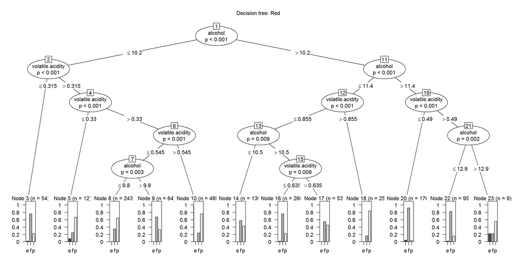

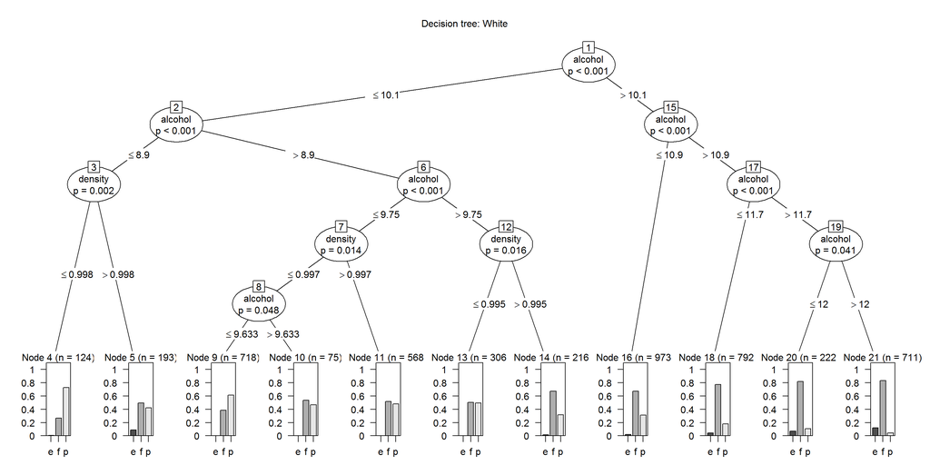

The output nodes have labels of e, f, p for excellent, fine and poor quality wines. Now using ctree and ramdom forest algorithm to predcit wine quality.

```
##               Red Wine White Wine
## Ctree        0.7156250  0.6438776
## RandomForest 0.7390625  0.7571429
```

The table above shows the accuracy of both the algorithms in predicting both Red and White wine quality. Random forest algorithm is better at predicting than ctree.

# Multivariate Analysis

### Talk about some of the relationships you observed in this part of the investigation. Were there features that strengthened each other in terms of looking at your feature(s) of interest?

I analyzed decision trees in predicting wine quality in this section. Used the correlation coefficient matrix to determine the input to the algorithms.

### OPTIONAL: Did you create any models with your dataset? Discuss the strengths and limitations of your model.

Created models from two different algorithms for predicting wine quality for each of the wine types. Computed the accuracy of the algorithm for comparison.

# Final Plots and Summary

### Plot One: Alcohol (%) in each quality level for Red and White Wines

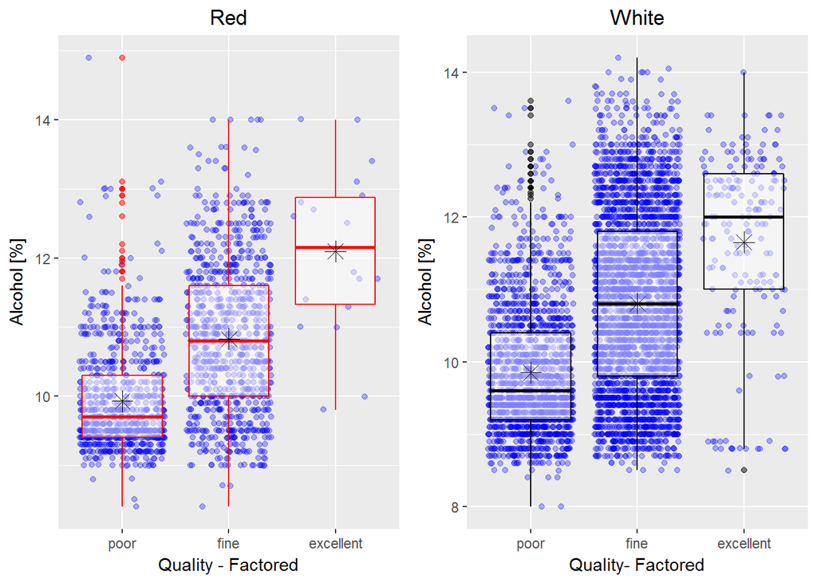

### Description One

Figure 1 shows the the distribution of alchohol percentage with respect to wine quality in both red and white wine. Wine quality improves with alcohol percentage. But, poor wines do have outliers with higher levels of alcohol. Mean of each quality factor is comparable between wine types. For both Red and White, fine wine’s mean and median is same, while for poor and excellent wine’s mean is shifted.

### Plot Two: Significant variables correlation for each quality level for Red and White wine

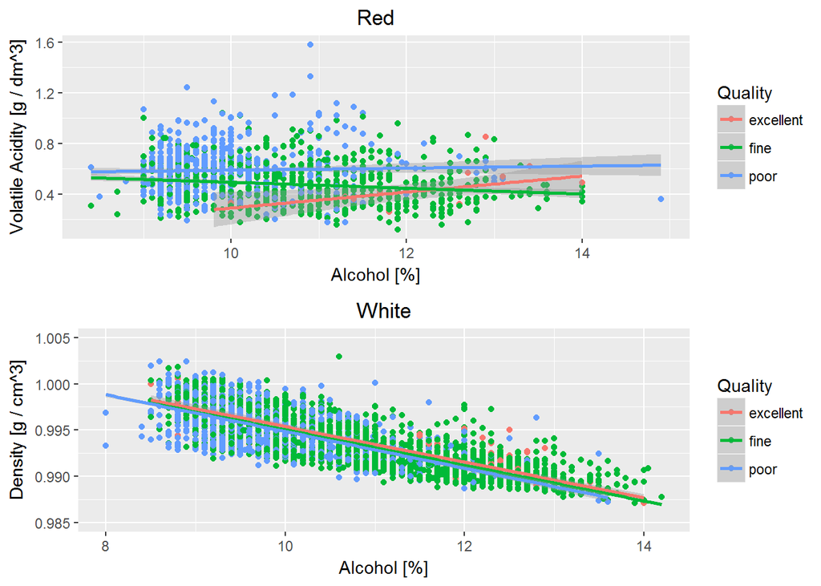

### Plot Three: Simple decision tree for quality for Red and White wine

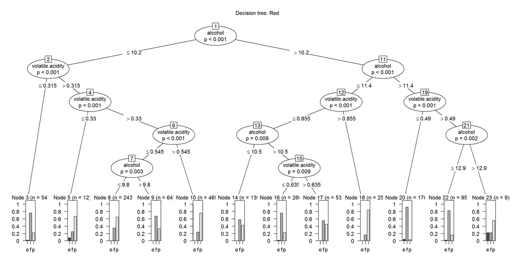

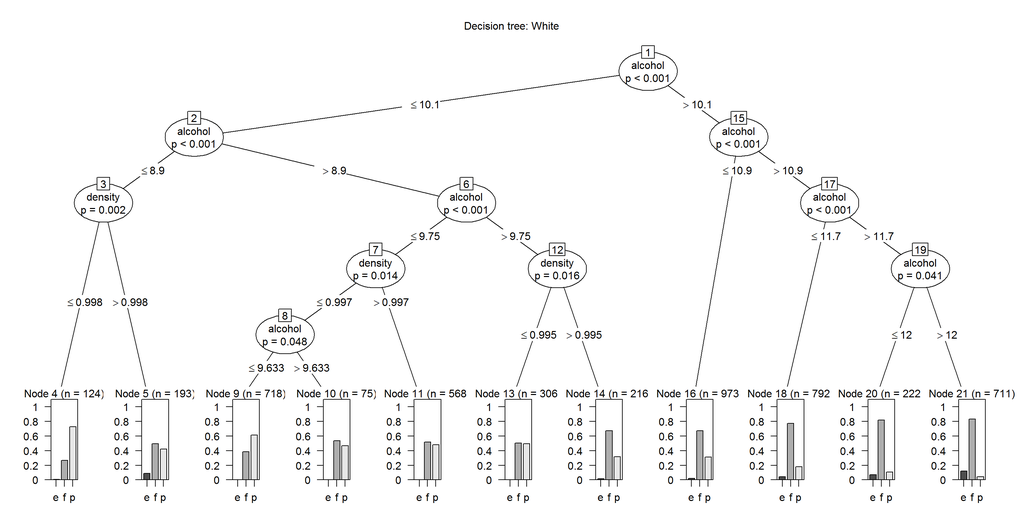

### Description Three

A simple decision matrix made with ctree algorithm is plotted in Figure 3 separately for Red and White wine. Again the input variables used here where chosen based on the significance in the correlation coeeficient matrix.

# Reflection

White and Red wine dataset was analyzed in the report. Initially explored one varaible at a time and then moved to multiple variables. Since the variables had numeric values I convereted couple of them into factors for exploration. The correlation matrix helped in determining the siginificant input variables. This really helped further the analysis and give it a direction. I struggled a bit in couple of areas. One in deciding what kind of plots would display the varible information efficiently and two making the plot pretty, with appropriate labels, titles and figure size. A little bit of research, and playing around with ggplot library functions helped finalizing the plots.

# References

Chang, Winston. n.d. “Cookbook-for-R.” http://www.cookbook-r.com/Graphs/Multiple{\_}graphs{\_}on{\_}one{\_}page{\_}(ggplot2)/.

Kassambra. n.d. “STHDA.” http://www.sthda.com/english/wiki/visualize-correlation-matrix-using-correlogram.

P. Cortez, A. Cerdeira, F. Almeida, T. Matos, and J. Reis. 2009. “Modeling wine preferences by data mining from physicochemical properties.” *Decision Support Systems, Elsevier* 47 (4): 547–53. http://dx.doi.org/10.1016/j.dss.2009.05.016.